# ANLT272_Final_Code_WG2

## Milestone 2 Table

**N**

```python
# At Index (N)
N_ad =  extraction2[(extraction2.at_ad_count > 0)].shape[0]
N_ac =  extraction2[(extraction2.at_ac_count > 0)].shape[0]
N_percent_ad = round(N_ad / extraction2.shape[0] * 100,2)
N_percent_ac = round(N_ac / extraction2.shape[0] *100,2)
N_both = extraction2[(extraction2.at_ad_count > 0) & (extraction2.at_ac_count > 0)].shape[0]
N_percent_both = round(N_both / extraction2.shape[0] * 100,2)
N_neither = extraction2[(extraction2.at_ad_count == 0) & (extraction2.at_ac_count == 0)].shape[0]
N_percent_neither = round(N_neither/extraction2.shape[0] *100,2)

N_row = ["N", N_ad, N_percent_ad, N_ac, N_percent_ac, N_both, N_percent_both, N_neither, N_percent_neither]
N_row
```

```
['N', 4904, 84.52, 898, 15.48, 201, 3.46, 201, 3.46]
```

**Males**

```python
M_ad =  extraction2[(extraction2.Gender=="M")& (extraction2.at_ad_count > 0)].shape[0]
M_ac =  extraction2[(extraction2.Gender=="M")& (extraction2.at_ac_count > 0)].shape[0]
M_percent_ad = round(M_ad / extraction2.shape[0] * 100,2)
M_percent_ac = round(M_ac / extraction2.shape[0] *100,2)
M_both = extraction2[(extraction2.Gender=="M")&(extraction2.at_ad_count > 0) & (extraction2.at_ac_count > 0)].shape[0]
M_percent_both = round(M_both / extraction2.shape[0] * 100,2)
M_neither = extraction2[(extraction2.Gender=="M")&(extraction2.at_ad_count == 0) & (extraction2.at_ac_count == 0)].shape[0]
M_percent_neither = round(M_neither/extraction2.shape[0] *100,2)

M_row = ["Males (n,%)", M_ad, M_percent_ad, M_ac, M_percent_ac, M_both, M_percent_both, M_neither, M_percent_neither]
M_row
```

```
['Males (n,%)', 2365, 40.76, 474, 8.17, 104, 1.79, 119, 2.05]
```

**Age 0-18 at Index**

```python
A18_ad =  extraction2[(extraction2.Age >= 0) & (extraction2.Age<=18) & (extraction2.at_ad_count > 0)].shape[0]
A18_ac =  extraction2[(extraction2.Age >= 0) & (extraction2.Age<=18) & (extraction2.at_ac_count > 0)].shape[0]
A18_percent_ad = round(A18_ad / extraction2.shape[0] * 100,2)
A18_percent_ac = round(A18_ac / extraction2.shape[0] *100,2)
A18_both = extraction2[(extraction2.Age >= 0) & (extraction2.Age<=18) &(extraction2.at_ad_count > 0) & (extraction2.at_ac_count > 0)].shape[0]
A18_percent_both = round(A18_both / extraction2.shape[0] * 100,2)
A18_neither = extraction2[(extraction2.Age >= 0) & (extraction2.Age<=18) &(extraction2.at_ad_count == 0) & (extraction2.at_ac_count == 0)].shape[0]
A18_percent_neither = round(A18_neither/extraction2.shape[0] *100,2)

A18_row = ["Age 0-18 at index (n,%)", A18_ad, A18_percent_ad, A18_ac, A18_percent_ac, A18_both, A18_percent_both, A18_neither, A18_percent_neither]
A18_row
```

```
['Age 0-18 at index (n,%)', 45, 0.78, 4, 0.07, 0, 0.0, 0, 0.0]
```

**Age 19-50 at Index**

```python
A50_ad =  extraction2[(extraction2.Age >= 19) & (extraction2.Age<=50) & (extraction2.at_ad_count > 0)].shape[0]
A50_ac =  extraction2[(extraction2.Age >= 19) & (extraction2.Age<=50) & (extraction2.at_ac_count > 0)].shape[0]
A50_percent_ad = round(A50_ad / extraction2.shape[0] * 100,2)
A50_percent_ac = round(A50_ac / extraction2.shape[0] *100,2)
A50_both = extraction2[(extraction2.Age >= 19) & (extraction2.Age<=50) &(extraction2.at_ad_count > 0) & (extraction2.at_ac_count > 0)].shape[0]
A50_percent_both = round(A50_both / extraction2.shape[0] * 100,2)
A50_neither = extraction2[(extraction2.Age >= 19) & (extraction2.Age<=50) &(extraction2.at_ad_count == 0) & (extraction2.at_ac_count == 0)].shape[0]
A50_percent_neither = round(A50_neither/extraction2.shape[0] *100,2)

A50_row = ["Age 19-50 at index (n,%)", A50_ad, A50_percent_ad, A50_ac, A50_percent_ac, A50_both, A50_percent_both, A50_neither, A50_percent_neither]
A50_row
```

```
['Age 19-50 at index (n,%)', 825, 14.22, 76, 1.31, 12, 0.21, 32, 0.55]
```

**Age 51-65 at Index**

```python
A65_ad =  extraction2[(extraction2.Age >= 51) & (extraction2.Age<=65) & (extraction2.at_ad_count > 0)].shape[0]
A65_ac =  extraction2[(extraction2.Age >= 51) & (extraction2.Age<=65) & (extraction2.at_ac_count > 0)].shape[0]
A65_percent_ad = round(A65_ad / extraction2.shape[0] * 100,2)
A65_percent_ac = round(A65_ac / extraction2.shape[0] *100,2)
A65_both = extraction2[(extraction2.Age >= 51) & (extraction2.Age<=65) &(extraction2.at_ad_count > 0) & (extraction2.at_ac_count > 0)].shape[0]
A65_percent_both = round(A65_both / extraction2.shape[0] * 100,2)
A65_neither = extraction2[(extraction2.Age >= 51) & (extraction2.Age<=65) &(extraction2.at_ad_count == 0) & (extraction2.at_ac_count == 0)].shape[0]
A65_percent_neither = round(A65_neither/extraction2.shape[0] *100,2)

A65_row = ["Age 51-65 at index (n,%)", A65_ad, A65_percent_ad, A65_ac, A65_percent_ac, A65_both, A65_percent_both, A65_neither, A65_percent_neither]
A65_row
```

```
['Age 51-65 at index (n,%)', 1756, 30.27, 220, 3.79, 52, 0.9, 56, 0.97]
```

**Age 66-75 at Index**

```python
A75_ad =  extraction2[(extraction2.Age >= 66) & (extraction2.Age<=75) & (extraction2.at_ad_count > 0)].shape[0]
A75_ac =  extraction2[(extraction2.Age >= 66) & (extraction2.Age<=75) & (extraction2.at_ac_count > 0)].shape[0]
A75_percent_ad = round(A75_ad / extraction2.shape[0] * 100,2)
A75_percent_ac = round(A75_ac / extraction2.shape[0] *100,2)
A75_both = extraction2[(extraction2.Age >= 66) & (extraction2.Age<=75) &(extraction2.at_ad_count > 0) & (extraction2.at_ac_count > 0)].shape[0]
A75_percent_both = round(A75_both / extraction2.shape[0] * 100,2)
A75_neither = extraction2[(extraction2.Age >= 66) & (extraction2.Age<=75) &(extraction2.at_ad_count == 0) & (extraction2.at_ac_count == 0)].shape[0]
A75_percent_neither = round(A75_neither/extraction2.shape[0] *100,2)

A75_row = ["Age 66-75 at index (n,%)", A75_ad, A75_percent_ad, A75_ac, A75_percent_ac, A75_both, A75_percent_both, A75_neither, A75_percent_neither]
A75_row
```

```
['Age 66-75 at index (n,%)', 1498, 25.82, 249, 4.29, 65, 1.12, 67, 1.15]
```

**Age 76+ at Index**

```python
A76_ad =  extraction2[(extraction2.Age >= 76) & (extraction2.at_ad_count > 0)].shape[0]
A76_ac =  extraction2[(extraction2.Age >= 76) & (extraction2.at_ac_count > 0)].shape[0]
A76_percent_ad = round(A76_ad / extraction2.shape[0] * 100,2)
A76_percent_ac = round(A76_ac / extraction2.shape[0] *100,2)
A76_both = extraction2[(extraction2.Age >= 76) & (extraction2.at_ad_count > 0) & (extraction2.at_ac_count > 0)].shape[0]
A76_percent_both = round(A76_both / extraction2.shape[0] * 100,2)
A76_neither = extraction2[(extraction2.Age >= 76) &(extraction2.at_ad_count == 0) & (extraction2.at_ad_count == 0)].shape[0]
A76_percent_neither = round(A76_neither/extraction2.shape[0] *100,2)

A76_row = ["Age 76+ at index (n,%)", A76_ad, A76_percent_ad, A76_ac, A76_percent_ac, A76_both, A76_percent_both, A76_neither, A76_percent_neither]
A76_row
```

```
['Age 76+ at index (n,%)', 780, 13.44, 349, 6.02, 72, 1.24, 323, 5.57]
```

**Pre Index: Pre Cardiol**

```python
pre_cardiol_ad =  extraction2[(extraction2.Pre_cardiol > 0) & (extraction2.at_ad_count > 0)].shape[0]
pre_cardiol_ac =  extraction2[(extraction2.Pre_cardiol > 0) & (extraction2.at_ac_count > 0)].shape[0]
pre_cardiol_percent_ad = round(pre_cardiol_ad / extraction2.shape[0] * 100,2)
pre_cardiol_percent_ac = round(pre_cardiol_ac / extraction2.shape[0] *100,2)
pre_cardiol_both = extraction2[(extraction2.Pre_cardiol > 0) & (extraction2.at_ac_count > 0) & (extraction2.at_ad_count > 0)].shape[0]
pre_cardiol_percent_both = round(pre_cardiol_both / extraction2.shape[0] * 100,2)
pre_cardiol_neither = extraction2[(extraction2.Pre_cardiol > 0) & (extraction2.at_ac_count == 0) & (extraction2.at_ad_count == 0)].shape[0]
pre_cardiol_percent_neither = round(pre_cardiol_neither/extraction2.shape[0] *100,2)

pre_cardiol_row = ["Pre_cardiol (n,%)", pre_cardiol_ad, pre_cardiol_percent_ad, pre_cardiol_ac, pre_cardiol_percent_ac, pre_cardiol_both, pre_cardiol_percent_both, pre_cardiol_neither, pre_cardiol_percent_neither]
pre_cardiol_row
```

```
['Pre_cardiol (n,%)', 915, 15.77, 413, 7.12, 94, 1.62, 57, 0.98]
```

**Pre Index: Pre_antihypertensive**

```python
pre_antihypertensive_ad =  extraction2[(extraction2.Pre_antihypertensive == 1) & (extraction2.at_ad_count > 0)].shape[0]
pre_antihypertensive_ac =  extraction2[(extraction2.Pre_antihypertensive == 1) & (extraction2.at_ac_count > 0)].shape[0]
pre_antihypertensive_percent_ad = round(pre_antihypertensive_ad / extraction2.shape[0] * 100,2)
pre_antihypertensive_percent_ac = round(pre_antihypertensive_ac / extraction2.shape[0] *100,2)
pre_antihypertensive_both = extraction2[(extraction2.Pre_antihypertensive == 1) & (extraction2.at_ad_count > 0) & (extraction2.at_ac_count > 0)].shape[0]
pre_antihypertensive_percent_both = round(pre_antihypertensive_both / extraction2.shape[0] * 100,2)
pre_antihypertensive_neither = extraction2[(extraction2.Pre_antihypertensive == 1) & (extraction2.at_ad_count == 0) & (extraction2.at_ad_count == 0)].shape[0]
pre_antihypertensive_percent_neither = round(pre_antihypertensive_neither/extraction2.shape[0] *100,2)

pre_antihypertensive_row = ["Pre_antihypertensive (n,%)", pre_antihypertensive_ad, pre_antihypertensive_percent_ad, pre_antihypertensive_ac, pre_antihypertensive_percent_ac, pre_antihypertensive_both, pre_antihypertensive_percent_both, pre_antihypertensive_neither, pre_antihypertensive_percent_neither]
pre_antihypertensive_row
```

```
['Pre_antihypertensive (n,%)', 2838, 48.91, 414, 7.14, 136, 2.34, 281, 4.84]
```

**Pre Index: Pre_IDX_HTN_Rx**

```python
Pre_IDX_HTN_Rx_ad = extraction2[(extraction2.at_ad_count > 0)]
Pre_IDX_HTN_Rx_ad_mean =  round(Pre_IDX_HTN_Rx_ad["Pre_IDX_HTN_Rx"].mean(), 2)
Pre_IDX_HTN_Rx_ad_sd =  round(Pre_IDX_HTN_Rx_ad["Pre_IDX_HTN_Rx"].std(), 2)

Pre_IDX_HTN_Rx_ac = extraction2[(extraction2.at_ac_count > 0)]
Pre_IDX_HTN_Rx_ac_mean =  round(Pre_IDX_HTN_Rx_ac["Pre_IDX_HTN_Rx"].mean(), 2)
Pre_IDX_HTN_Rx_ac_sd =  round(Pre_IDX_HTN_Rx_ac["Pre_IDX_HTN_Rx"].std(), 2)

Pre_IDX_HTN_Rx_both = extraction2[(extraction2.at_ad_count > 0) & (extraction2.at_ac_count > 0)]
Pre_IDX_HTN_Rx_both_mean =  round(Pre_IDX_HTN_Rx_both["Pre_IDX_HTN_Rx"].mean(), 2)
Pre_IDX_HTN_Rx_both_sd =  round(Pre_IDX_HTN_Rx_both["Pre_IDX_HTN_Rx"].std(), 2)

Pre_IDX_HTN_Rx_neither = extraction2[(extraction2.at_ad_count == 0) & (extraction2.at_ad_count == 0)]
Pre_IDX_HTN_Rx_neither_mean = round(Pre_IDX_HTN_Rx_neither["Pre_IDX_HTN_Rx"].mean(), 2)
Pre_IDX_HTN_Rx_neither_sd =  round(Pre_IDX_HTN_Rx_neither["Pre_IDX_HTN_Rx"].std(skipna=True), 2)

Pre_IDX_HTN_Rx_row = ["Pre_IDX_HTN_Rx (mean, SD)", Pre_IDX_HTN_Rx_ad_mean, Pre_IDX_HTN_Rx_ad_sd, Pre_IDX_HTN_Rx_ac_mean, Pre_IDX_HTN_Rx_ac_sd,Pre_IDX_HTN_Rx_both_mean,Pre_IDX_HTN_Rx_both_sd, Pre_IDX_HTN_Rx_neither_mean,Pre_IDX_HTN_Rx_neither_sd]
Pre_IDX_HTN_Rx_row
```

```
['Pre_IDX_HTN_Rx (mean, SD)', 2.17, 2.71, 1.74, 2.54, 2.74, 2.75, 1.14, 2.21]
```

**Post Index: Post_IDX_Rx**

```python
Post_IDX_Rx_ad = extraction2[(extraction2.at_ad_count > 0)]
Post_IDX_Rx_ad_mean =  round(Pre_IDX_HTN_Rx_ad["Post_IDX_Rx_ad"].mean(), 2)
Post_IDX_Rx_ad_sd =  round(Pre_IDX_HTN_Rx_ad["Post_IDX_Rx_ad"].std(), 2)

Post_IDX_Rx_ac = extraction2[(extraction2.at_ac_count > 0)]
Post_IDX_Rx_ac_mean =  round(Post_IDX_Rx_ac["Post_IDX_Rx_ac"].mean(), 2)
Post_IDX_Rx_ac_sd =  round(Post_IDX_Rx_ac["Post_IDX_Rx_ac"].std(), 2)

Post_IDX_Rx_both = extraction2[(extraction2.at_ad_count > 0) & (extraction2.at_ac_count > 0)]
stack_both = pd.concat([Post_IDX_Rx_both['Post_IDX_Rx_ac'], Post_IDX_Rx_both['Post_IDX_Rx_ad']], axis=0)
Post_IDX_Rx_both_mean =  round(stack_both.mean(), 2)
Post_IDX_Rx_both_sd = round(stack_both.std(),2)

Post_IDX_Rx_neither = extraction2[(extraction2.at_ad_count == 0) & (extraction2.at_ad_count == 0)]
stack_neither = pd.concat([Post_IDX_Rx_neither['Post_IDX_Rx_ac'], Post_IDX_Rx_neither['Post_IDX_Rx_ad']], axis=0)
Post_IDX_Rx_neither_mean = round(stack_neither.mean(),2)
Post_IDX_Rx_neither_sd = round(stack_neither.std(),2)

Post_IDX_Rx_row = ["Post_IDX_Rx (mean, SD)",Post_IDX_Rx_ad_mean, Post_IDX_Rx_ad_sd, Post_IDX_Rx_ac_mean, Post_IDX_Rx_ac_sd,Post_IDX_Rx_both_mean,Post_IDX_Rx_both_sd, Post_IDX_Rx_neither_mean,Post_IDX_Rx_neither_sd]
Post_IDX_Rx_row
```

```
['Post_IDX_Rx (mean, SD)', 1.88, 2.17, 1.94, 2.09, 1.85, 2.12, 1.98, 2.1]
```

**Post Index: Post_IDX_DS**

```python
Post_IDX_DS_ad = extraction2[(extraction2.at_ad_count > 0)]
Post_IDX_DS_ad_mean =  round(Post_IDX_DS_ad["Post_IDX_DS_ad"].mean(), 2)
Post_IDX_DS_ad_sd =  round(Post_IDX_DS_ad["Post_IDX_DS_ad"].std(), 2)

Post_IDX_DS_ac = extraction2[(extraction2.at_ac_count > 0)]
Post_IDX_DS_ac_mean =  round(Post_IDX_DS_ac["Post_IDX_DS_ac"].mean(), 2)
Post_IDX_DS_ac_sd =  round(Post_IDX_DS_ac["Post_IDX_DS_ac"].std(), 2)

Post_IDX_DS_both = extraction2[(extraction2.at_ad_count > 0) & (extraction2.at_ac_count > 0)]
stack_DS_both = pd.concat([Post_IDX_DS_both['Post_IDX_DS_ac'], Post_IDX_Rx_both['Post_IDX_DS_ad']], axis=0)
Post_IDX_DS_both_mean =  round(stack_DS_both.mean(), 2)
Post_IDX_DS_both_sd = round(stack_DS_both.std(),2)

Post_IDX_DS_neither = extraction2[(extraction2.at_ad_count == 0) & (extraction2.at_ad_count == 0)]
stack_DS_neither = pd.concat([Post_IDX_DS_neither['Post_IDX_DS_ac'], Post_IDX_DS_neither['Post_IDX_DS_ad']], axis=0)
Post_IDX_DS_neither_mean = round(stack_DS_neither.mean(),2)
Post_IDX_DS_neither_sd = round(stack_DS_neither.std(),2)

Post_IDX_DS_row = ["Post_IDX_DS (mean, SD)",Post_IDX_DS_ad_mean, Post_IDX_DS_ad_sd, Post_IDX_DS_ac_mean, Post_IDX_DS_ac_sd,Post_IDX_DS_both_mean,Post_IDX_DS_both_sd, Post_IDX_DS_neither_mean,Post_IDX_DS_neither_sd]
Post_IDX_DS_row
```

```
['Post_IDX_DS (mean, SD)',
 77.86,
 80.21,
 82.91,
 81.39,
 77.29,
 78.1,
 84.38,
 81.84]
```

**Post Index: IDX_PDC**

```python
Post_IDX_PDC_ad = extraction2[(extraction2.at_ad_count > 0)]
Post_IDX_PDC_ad_mean =  round(Post_IDX_PDC_ad["IDX_PDC_ad"].mean(), 2)
Post_IDX_PDC_ad_sd =  round(Post_IDX_PDC_ad["IDX_PDC_ad"].std(), 2)

Post_IDX_PDC_ac = extraction2[(extraction2.at_ac_count > 0)]
Post_IDX_PDC_ac_mean =  round(Post_IDX_PDC_ac["IDX_PDC_ac"].mean(), 2)
Post_IDX_PDC_ac_sd =  round(Post_IDX_PDC_ac["IDX_PDC_ac"].std(), 2)

Post_IDX_PDC_both = extraction2[(extraction2.at_ad_count > 0) & (extraction2.at_ac_count > 0)]
stack_PDC_both = pd.concat([Post_IDX_PDC_both['IDX_PDC_ac'], Post_IDX_PDC_both['IDX_PDC_ad']], axis=0)
Post_IDX_PDC_both_mean =  round(stack_PDC_both.mean(), 2)
Post_IDX_PDC_both_sd = round(stack_PDC_both.std(),2)

Post_IDX_PDC_neither = extraction2[(extraction2.at_ad_count == 0) & (extraction2.at_ad_count == 0)]
stack_PDC_neither = pd.concat([Post_IDX_PDC_neither['IDX_PDC_ac'], Post_IDX_PDC_neither['IDX_PDC_ad']], axis=0)
Post_IDX_PDC_neither_mean = round(stack_PDC_neither.mean(),2)
Post_IDX_PDC_neither_sd = round(stack_PDC_neither.std(),2)

Post_IDX_PDC_row = ["IDX_PDC (mean, SD)",Post_IDX_PDC_ad_mean, Post_IDX_PDC_ad_sd, Post_IDX_PDC_ac_mean, Post_IDX_PDC_ac_sd,Post_IDX_PDC_both_mean,Post_IDX_PDC_both_sd, Post_IDX_PDC_neither_mean,Post_IDX_PDC_neither_sd]
Post_IDX_PDC_row
```

```
['IDX_PDC (mean, SD)', 0.43, 0.45, 0.46, 0.45, 0.43, 0.43, 0.47, 0.45]
```

**Post Index: IDX_PDC>80**

```python
IDX_PDC_80_ad =  extraction2[(extraction2.IDX_PDC_80_ad > 0) & (extraction2.at_ad_count > 0)].shape[0]
IDX_PDC_80_ac =  extraction2[(extraction2.IDX_PDC_80_ac > 0) & (extraction2.at_ac_count > 0)].shape[0]
IDX_PDC_80_percent_ad = round(IDX_PDC_80_ad / extraction2.shape[0] * 100,2)
IDX_PDC_80_percent_ac = round(IDX_PDC_80_ac / extraction2.shape[0] *100,2)
IDX_PDC_80_both = extraction2[(extraction2.IDX_PDC_80_ad > 0)&(extraction2.IDX_PDC_80_ac > 0) & (extraction2.at_ad_count > 0) & (extraction2.at_ac_count > 0)].shape[0]
IDX_PDC_80_percent_both = round(IDX_PDC_80_both / extraction2.shape[0] * 100,2)
IDX_PDC_80_neither = extraction2[(extraction2.IDX_PDC_80_ad == 1)&(extraction2.IDX_PDC_80_ac == 1) & (extraction2.at_ad_count == 0) & (extraction2.at_ad_count == 0)].shape[0]
IDX_PDC_80_percent_neither = round(IDX_PDC_80_neither/extraction2.shape[0] *100,2)

IDX_PDC_80_row = ["IDX_PDC>80 (n,%)", IDX_PDC_80_ad, IDX_PDC_80_percent_ad, IDX_PDC_80_ac, IDX_PDC_80_percent_ac, IDX_PDC_80_both, IDX_PDC_80_percent_both, IDX_PDC_80_neither, IDX_PDC_80_percent_neither]
IDX_PDC_80_row
```

```
['IDX_PDC>80 (n,%)', 1387, 23.91, 271, 4.67, 17, 0.29, 0, 0.0]
```

**Post Index: Post_MI**

```python
Post_MI_ad =  extraction2[(extraction2.Post_MI > 0) & (extraction2.at_ad_count > 0)].shape[0]
Post_MI_ac =  extraction2[(extraction2.Post_MI > 0) & (extraction2.at_ac_count > 0)].shape[0]
Post_MI_percent_ad = round(Post_MI_ad / extraction2.shape[0] * 100,2)
Post_MI_percent_ac = round(Post_MI_ac / extraction2.shape[0] *100,2)
Post_MI_both = extraction2[(extraction2.Post_MI == 1) & (extraction2.at_ad_count > 0) & (extraction2.at_ac_count > 0)].shape[0]
Post_MI_percent_both = round(Post_MI_both / extraction2.shape[0] * 100,2)
Post_MI_neither = extraction2[(extraction2.Post_MI == 1) & (extraction2.at_ad_count == 0) & (extraction2.at_ad_count == 0)].shape[0]
Post_MI_percent_neither = round(Post_MI_neither/extraction2.shape[0] *100,2)

Post_MI_row = ["Post_MI (n,%)", Post_MI_ad, Post_MI_percent_ad, Post_MI_ac, Post_MI_percent_ac, Post_MI_both, Post_MI_percent_both, Post_MI_neither, Post_MI_percent_neither]
Post_MI_row
```

```
['Post_MI (n,%)', 0, 0.0, 0, 0.0, 0, 0.0, 0, 0.0]
```

```python
# Converting lists to a data frame
my_frame = pd.DataFrame([N_row, M_row, A18_row, A50_row, A65_row, A75_row, A76_row, pre_cardiol_row, pre_antihypertensive_row, Pre_IDX_HTN_Rx_row,Post_IDX_Rx_row, Post_IDX_DS_row, Post_IDX_PDC_row,IDX_PDC_80_row,Post_MI_row ],
                   columns=['Variable', 'AD n', 'AD %', 'AC n', 'AC %', 'Both n', 'Both %', 'Neither n', 'Neither %']).set_index("Variable")

# Print out of html code for the table of values
#print(my_frame.to_html())
```

**Markdown of HTML Table Code From Above**

| Variable | AD n | AD % | AC n | AC % | Both n | Both % | Neither n | Neither % |
| --- | --- | --- | --- | --- | --- | --- | --- | --- |
| N | 4904.00 | 84.52 | 898.00 | 15.48 | 201.00 | 3.46 | 201.00 | 3.46 |
| Males (n,%) | 2365.00 | 40.76 | 474.00 | 8.17 | 104.00 | 1.79 | 119.00 | 2.05 |
| Age 0-18 at index (n,%) | 45.00 | 0.78 | 4.00 | 0.07 | 0.00 | 0.00 | 0.00 | 0.00 |
| Age 19-50 at index (n,%) | 825.00 | 14.22 | 76.00 | 1.31 | 12.00 | 0.21 | 32.00 | 0.55 |
| Age 51-65 at index (n,%) | 1756.00 | 30.27 | 220.00 | 3.79 | 52.00 | 0.90 | 56.00 | 0.97 |
| Age 66-75 at index (n,%) | 1498.00 | 25.82 | 249.00 | 4.29 | 65.00 | 1.12 | 67.00 | 1.15 |
| Age 76+ at index (n,%) | 780.00 | 13.44 | 349.00 | 6.02 | 72.00 | 1.24 | 323.00 | 5.57 |
| Pre_cardiol (n,%) | 915.00 | 15.77 | 413.00 | 7.12 | 94.00 | 1.62 | 57.00 | 0.98 |
| Pre_antihypertensive (n,%) | 2838.00 | 48.91 | 414.00 | 7.14 | 136.00 | 2.34 | 281.00 | 4.84 |
| Pre_IDX_HTN_Rx (mean, SD) | 2.17 | 2.71 | 1.74 | 2.54 | 2.74 | 2.75 | 1.14 | 2.21 |
| Post_IDX_Rx (mean, SD) | 1.88 | 2.17 | 1.94 | 2.09 | 1.85 | 2.12 | 1.98 | 2.10 |
| Post_IDX_DS (mean, SD) | 77.86 | 80.21 | 82.91 | 81.39 | 77.29 | 78.10 | 84.38 | 81.84 |
| IDX_PDC (mean, SD) | 0.43 | 0.45 | 0.46 | 0.45 | 0.43 | 0.43 | 0.47 | 0.45 |
| IDX_PDC>80 (n,%) | 1387.00 | 23.91 | 271.00 | 4.67 | 17.00 | 0.29 | 0.00 | 0.00 |
| Post_MI (n,%) | 0.00 | 0.00 | 0.00 | 0.00 | 0.00 | 0.00 | 0.00 | 0.00 |

# Milestone 1 Table

| Variable | IDX Group Anti-Diabetic n | IDX Group Anti-Diabetic % | IDX Group Anticoagulant n | IDX Group Anticoagulant % | IDX Group Both n | IDX Group Both % | IDX Group Neither n | IDX Group Neither % |
| --- | --- | --- | --- | --- | --- | --- | --- | --- |
| **N** | 4950 | 85.32 | 1046 | 18.03 | 392 | 6.76 | 198 | 3.41 |
| **Male (n,%)** | 2390 | 83.74 | 556 | 19.48 | 211 | 7.39 | 119 | 4.17 |
| **Age 0-18 at index (n,%)** | 45 | 91.84 | 4 | 8.16 | 0 | 0 | 0 | 0 |
| **Age 19-50 at index (n,%)** | 829 | 90.01 | 86 | 9.34 | 26 | 2.82 | 32 | 3.47 |
| **Age 51-65 at index (n,%)** | 1766 | 89.28 | 255 | 12.89 | 98 | 4.95 | 55 | 2.78 |
| **Age 66-75 at index (n,%)** | 1514 | 86.56 | 309 | 17.67 | 140 | 8 | 66 | 3.77 |
| **Age 76+ at index (n,%)** | 794 | 71.99 | 392 | 35.54 | 128 | 11.6 | 45 | 4.08 |

# Milestone 2 Table

|  | **Variable** | IDX Group **Anti-Diabetic** **n** | IDX Group **Anti-Diabetic** **%** | IDX Group **Anticoagulant** **n** | IDX Group **Anticoagulant** **%** | IDX Group **Both** **n** | IDX Group **Both** **%** | IDX Group **Neither** **n** | IDX Group **Neither** **%** |
| --- | --- | --- | --- | --- | --- | --- | --- | --- | --- |
| **At Index** | **N** | 4904 | 84.52 | 898 | 15.48 | 201 | 3.46 | 201 | 3.46 |
|  | **Male (n,%)** | 2365 | 40.76 | 474 | 8.17 | 104 | 1.79 | 119 | 2.05 |
|  | **Age 0-18 at index (n,%)** | 45 | 0.78 | 4 | 0.07 | 0 | 0 | 0 | 0 |
|  | **Age 19-50 at index (n,%)** | 825 | 14.22 | 76 | 1.31 | 12 | 0.21 | 32 | 0.55 |
|  | **Age 51-65 at index (n,%)** | 1756 | 30.27 | 220 | 3.79 | 52 | 0.9 | 56 | 0.97 |
|  | **Age 66-75 at index (n,%)** | 1498 | 25.82 | 249 | 4.29 | 65 | 1.12 | 67 | 1.15 |
|  | **Age 76+ at index (n,%)** | 780 | 13.44 | 349 | 6.02 | 72 | 1.24 | 323 | 5.57 |
| **Pre-Index** | **Pre_cardiol (n, %)** | 915 | 15.77 | 413 | 7.12 | 94 | 1.62 | 57 | 0.98 |
|  | **Pre_antihypertensive (n, %)** | 2838 | 48.91 | 414 | 7.14 | 136 | 2.34 | 281 | 4.84 |
|  |  | **Mean** | **SD** | **Mean** | **SD** | **Mean** | **SD** | **Mean** | **SD** |
|  | **Pre_IDX_HTN_Rx (Mean, SD)** | 2.17 | 2.71 | 1.74 | 2.54 | 2.74 | 2.75 | 1.14 | 2.21 |
| **Post-Index** | **Post_IDX_Rx (Mean, SD)** | 1.88 | 2.17 | 1.94 | 2.09 | 1.85 | 2.12 | 1.98 | 2.10 |
|  | **Post_IDX_DS (Mean, SD)** | 77.86 | 80.21 | 82.91 | 81.39 | 77.29 | 78.10 | 84.38 | 81.84 |
|  | **IDX_PDC (Mean, SD)** | 0.43 | 0.45 | 0.46 | 0.45 | 0.43 | 0.43 | 0.47 | 0.45 |
|  |  | **n** | **%** | **n** | **%** | **n** | **%** | **n** | **%** |
|  | **IDX_PDC>80 (n,%)** | 1387 | 23.91 | 271 | 4.67 | 17 | 0.29 | 0 | 0.00 |
|  | **Post_MI (n, %)** | 0 | 0.00 | 0 | 0.00 | 0 | 0.00 | 0 | 0.00 |

# Making Plots

```python
import plotly.graph_objects as go
x=[len(ac_list), len(ad_list), len(htn_list)]
y=['Anticoagulants', 'Antidiabetics', 'Antihypertensives']
fig = go.Figure(go.Bar(
            x=x,
            y=y,
            text=x,
            textposition='auto',
            orientation='h',
            marker=dict(color= '#1BDD9F')))
fig.update_layout(title='Count of NDC Drug Groups',
                    xaxis_title='Number of NDCs',
                    plot_bgcolor='white')
fig.show()
```

[interactive chart not shown]

```python
at_pt = claims[(claims['from_dt'] >= '2013-01-01') & (claims['from_dt'] <= '2013-03-31')]
pre_pt = claims[(claims['from_dt'] >= '2012-07-01') & (claims['from_dt'] <= '2012-12-31')]
post_pt = claims[(claims['from_dt'] >= '2013-04-01') & (claims['from_dt'] <= '2013-09-30')]

print("Number of At Index Claims:", at_pt.shape[0])
print("Number of Pre Index Claims:", pre_pt.shape[0])
print("Number of Post Index Claims:", post_pt.shape[0])

def Count_Claims_At(pt):
    at_d = at_pt.loc[at_pt.pat_id == pt] # Subsetting claims that belong to each unique patient
    return(at_d.shape[0]) # The number of rows within the subset will indicate the number of claims

def Count_Claims_Pre(pt):
    pre_d = pre_pt.loc[pre_pt.pat_id == pt] # Subsetting claims that belong to each unique patient
    return(pre_d.shape[0])

def Count_Claims_Post(pt):
    post_d = post_pt.loc[post_pt.pat_id == pt] # Subsetting claims that belong to each unique patient
    return(post_d.shape[0])


females = extraction2[extraction2.Gender=="F"]  # Female patients
males = extraction2[extraction2.Gender=="M"]    # Male patients

female_df = pd.DataFrame()
female_df["female_claims_at"] = females.pat_id.apply(lambda x: Count_Claims_At(str(x)))
female_df["female_claims_pre"] = females.pat_id.apply(lambda x: Count_Claims_Pre(str(x)))
female_df["female_claims_post"] = females.pat_id.apply(lambda x: Count_Claims_Post(str(x)))

male_df = pd.DataFrame()
male_df["male_claims_at"] = males.pat_id.apply(lambda x: Count_Claims_At(str(x)))
male_df["male_claims_pre"] = males.pat_id.apply(lambda x: Count_Claims_Pre(str(x)))
male_df["male_claims_post"] = males.pat_id.apply(lambda x: Count_Claims_Post(str(x)))

at_females = female_df["female_claims_at"].sum()
pre_females = female_df["female_claims_pre"].sum()
post_females = female_df["female_claims_post"].sum()

at_males = male_df["male_claims_at"].sum()
pre_males = male_df["male_claims_pre"].sum()
post_males = male_df["male_claims_post"].sum()
```

```
Number of At Index Claims: 194452
Number of Pre Index Claims: 335771
Number of Post Index Claims: 321692
```

```python
import plotly.graph_objects as go

fig = go.Figure()
fig.update_xaxes(showgrid=False)
fig.update_yaxes(showgrid=False)
fig.add_trace(go.Bar(
    y=["At", "Pre", "Post"],
    x=[at_females, pre_females, post_females],
    name='Females',
    orientation='h',
    marker=dict(color= '#1BDD9F')))

fig.add_trace(go.Bar(
    y=["At", "Pre", "Post"],
    x=[at_males, pre_males, post_males],
    name='Males',
    orientation='h',
    marker=dict(
        color='rgba(58, 71, 80, 0.6)')))

fig.update_layout(title='Claims Count by Index Period',
                    xaxis_title='Number of Claims',
                    plot_bgcolor='white',
                    legend=dict(
                    orientation="h",
                    yanchor="bottom",
                    y=1.02,
                    xanchor="right",
                    x=1))


fig.update_layout(barmode='stack')
fig.show()
```

[interactive chart not shown]

# Naive Bayes Classifier

```python
# The "Extract.csv" is really the DataExtract Excel file from Canvas converted to a csv format
data = pd.read_csv("Extract.csv", usecols =["pdc", "sexN", "age_cat", "DIABETES", "HYPERTENSION","CARDIAC_ARRYTHMIA", "CARDIAC_VALVULAR","CHF", "COPD", "MI_CAD"])
data.head(5)
```

|  | pdc | sexN | age_cat | CARDIAC_ARRYTHMIA | CARDIAC_VALVULAR | CHF | COPD | DIABETES | HYPERTENSION | MI_CAD |
| --- | --- | --- | --- | --- | --- | --- | --- | --- | --- | --- |
| 0 | 0.894444 | 2 | 1 | 0 | 0 | 0 | 0 | 0 | 0 | 0 |
| 1 | 0.333333 | 2 | 2 | 0 | 0 | 0 | 0 | 1 | 0 | 0 |
| 2 | 0.077778 | 1 | 4 | 0 | 0 | 0 | 0 | 0 | 1 | 0 |
| 3 | 0.333333 | 1 | 3 | 0 | 0 | 0 | 0 | 1 | 1 | 0 |
| 4 | 0.866667 | 1 | 2 | 0 | 0 | 0 | 0 | 0 | 0 | 0 |

```python
from sklearn import preprocessing
from sklearn.model_selection import train_test_split
from sklearn.metrics import accuracy_score
from sklearn.naive_bayes import GaussianNB
from statistics import mean
from imblearn.over_sampling import RandomOverSampler

def naiveGaussian(X, Y, testProportion=0.2):

    # Splitting df into train and test sets
    X_train, X_test, y_train, y_test = train_test_split(X, Y, test_size=testProportion)

    # Correcting data imbalances with random oversampling
    ros = RandomOverSampler()
    X_train, y_train = ros.fit_resample(X_train, y_train)

    # fitting the inputs into Naive Bayes model
    gnb = GaussianNB()
    y_pred = gnb.fit(X_train, y_train).predict(X_test)

    # accuracy scores of fitted model
    accuracy = accuracy_score(y_test, y_pred)
    return(accuracy)
```

```python
x = data[["pdc", "sexN", "age_cat", "DIABETES", "HYPERTENSION","CARDIAC_ARRYTHMIA", "CARDIAC_VALVULAR","CHF", "COPD"]]
y = data[["MI_CAD"]]

scores =[]
for i in range(20):
    score = naiveGaussian(x,y)
    scores.append(score)

# Average Accuracy Score
print("Average Accuracy Score:", round(mean(scores)*100, 2), "%")
```

```
Average Accuracy Score: 87.38 %
```

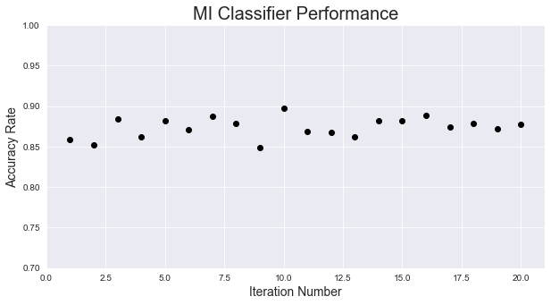

```python
import seaborn as sns
import matplotlib.pyplot as plt
sns.set_style('darkgrid')

x= range(1,21)
plt.figure(figsize=(10,5))
plt.plot(x, scores, 'o', color='black')
plt.title("MI Classifier Performance", size=20)
plt.xlabel("Iteration Number", size=14)
plt.ylabel("Accuracy Rate", size=14)
plt.xlim(0,21)
plt.ylim(0.7,1)
plt.show()
```

**Works Cited**

For loop

- https://stackoverflow.com/questions/11479392/what-does-a-for-loop-within-a-list-do-in-python

Converting pandas dataframe to a markdown table

- https://stackoverflow.com/questions/33181846/programmatically-convert-pandas-dataframe-to-markdown-table

Finding earliest date

- https://www.w3resource.com/python-exercises/pandas/datetime/pandas-datetime-exercise-3.php

Finding rows that contain an item that is also in a criteria list

- https://stackoverflow.com/questions/17071871/how-to-select-rows-from-a-dataframe-based-on-column-values

Filtering dates in a dataframe

- https://stackoverflow.com/questions/22898824/filtering-pandas-dataframes-on-dates

Merging dataframes

- https://www.analyticsvidhya.com/blog/2020/02/joins-in-pandas-master-the-different-types-of-joins-in-python/

Creating a column indicating which index the patient is associated with

- https://www.dataquest.io/blog/tutorial-add-column-pandas-dataframe-based-on-if-else-condition/
- https://www.kite.com/python/answers/how-to-replace-column-values-in-a-pandas-dataframe-in-python